# Classification tehniques II: logistic regression, LDA & QDA

Chiricu Ana-Bianca (Gr 405)

Poinarita Andreea-Diana (Gr 405)

07 ianuarie 2023

## **1. Regresia logistica**

##### *Definitie*

Regresia logistica este o metoda potrivita pentru a modela relatia dintre o multime de variabile independente X si o variabila dependenta, binara, Y, reprezentand apartenenta la doua clase/categorii – da/nu, prezent/absent, adevarat/fals. Din acest motiv, putem “coda” valorile lui Y cu 0 sau 1, valoarea 1 reprezentand aparitia/realizarea evenimentului respectiv. Prin urmare, scopul este gasirea probabilitatii de producere a evenimentului in functie de valorile variabilelor independente X.

In cazul in care exista un singur predictor/variabila independenta, modelul se bazeaza pe functia logistica urmatoare:

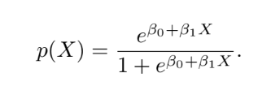

(figura 4.2, pg. 134).

Aceasta functie genereaza o valoare dependenta in intervalul (0,1) pentru orice valoare arbitrara a variabilei independente, reprezentand, de fapt, probabilitatea de incadrare a valorii independente in una din cele doua categorii ale variabilei dependente.

Pentru a se antrena modelul, se foloseste o metoda numita probabilitate maxima (maximum likelihood), adica estimam valorile coeficientilor b0 si b1 astfel incat p(X) are o valoare cat mai aproape de 1 pentru success si cat mai aproape de 0 in caz de esec. Dupa stabilirea coeficientilor, se pot face predictii/ se poate calcula probabilitatea.

De asemenea, pe baza functiei logistice, exista o notiune numita “odds” (raport de sanse) care este, de fapt, probabilitatea de succes(1) impartita la probabilitatea de esec (0):

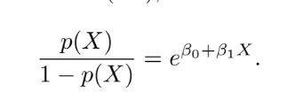

(figura 4.3, pg. 134)

In general, regresia logistica este un model folosit pentru 2 clase, insa se poate extinde/generaliza la mai multe clase, adica Multinomial Logistic Regression.

In limbajul R: - un model se poate antrena astfel, folosind functia glm.fits: **

```
 glm.fits <- glm (Direction ~ (Lag1 + Lag2 + Lag3 + Lag4 + Lag5 + Volume) ,data = Smarket , family =binomial)
```

- coeficientii gasiti se pot vizualiza prin functia coef (glm.fits)

```
coef(glm.fits)
```

- rezultatul poate fi gasit prin folosirea functiei predict

```
glm.probs <- predict (glm.fits , type = " response ")
glm.probs[1:10]
```

## **2. LDA**

##### *Definitie*

LDA for p=1:

- estimarea fk(X) largest
- e liniar pentru ca (figura 4.18 pg 143) e o functie liniara

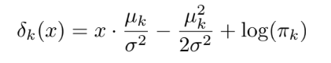

- Limita de decizie: este unctul pentru care δ1(x) = δ2(x);

Metoda analizei discriminante liniară (LDA) aproximează clasificatorul Bayes prin introducerea estimărilor pentru πk, µk și σ2 în (4.18).

LDA for p>1:

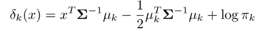

(figura 4.24. pagina146)

- LDA presupune că observațiile din cadrul fiecărei clase sunt extrase dintr-o distribuție Gaussiană multivariată cu un vector mediu specific clasei și o matrice de covarianță care este comună tuturor claselor K.

```
LDA: lda.fit <- lda
```

## **3. QDA**

##### *Definitie*

- functia quadratica de aici si numele

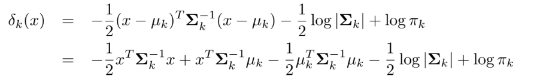

La fel ca LDA, clasificatorul QDA rezultă din presupunerea că observațiile din fiecare clasă sunt extrase dintr-o distribuție Gaussiană și din introducerea estimărilor pentru parametri în teorema lui Bayes pentru a realiza predicția. Cu toate acestea, spre deosebire de LDA, QDA presupune că fiecare clasă are propria sa matrice de covarianță.

```
 QDA: qda.fit <- qda
```

## **4. Comparatie**

- LDA este un clasificator mult mai puțin flexibil decât QDA și deci are o varianță substanțial mai mică. Acest lucru poate duce la îmbunătățirea performanța de predicție. Dar există un compromis: dacă LDA presupune că clasele K au o matrice de covarianță comună, atunci LDA poate suferi de un bias mare. În linii mari, LDA tinde să fie o varianta mai buna decât QDA dacă există relativ puține observații de antrenament și astfel reducerea varianței este crucială. În schimb, QDA este recomandat dacă setul de antrenament este foarte mare, astfel încât varianța clasificatorului să nu fie o preocupare majoră, sau dacă ipoteza unei matrice de covarianță comună pentru clasele K este clară de nesuportat.
- LDA si QDA sunt potrivire pentru raspunsuri calitative dar care au mai multe clase
- LDA & QDA: se bazeaza pe means si pe variance
- Represia logistica este potrivita in special pentru clasificarile cu doua clase sau binare. Asa cum am mentionat anterior, aceasta poate fi extinsa pentru clasificarea cu mai multe clase, dar este rar folosit astfel.
- Regresia logistica poate sa fie instabila atunci cand clasele sunt bine separate sau cand exista putine exemple din care sa fie estimati coeficientii/parametri.

## **5. Exercitii**

##### *1. Cerinta:*

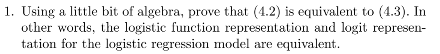

##### *1. Rezolvare:*

$$\begin{aligned}
P(x)(1+^{\beta_0 + \beta_1x}) &= e^{\beta_0 + \beta_1x}\\
\frac{P(x)}{\frac{1}{1 + e^{\beta_0 + \beta_1x}}} &= e^{\beta_0
+ \beta_1x}\\
\frac{P(x)}{1 - \frac{e^{\beta_0 + \beta_1x}}{1+ e^{\beta_0 +
\beta_1x}}} &= e^{\beta_0 + \beta_1x}\\
\frac{P(x)}{1 - P(x)} &= e^{\beta_0 + \beta_1x}\\
\end{aligned}$$

##### *2. Cerinta:*

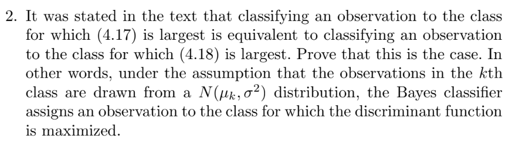

##### *2. Rezolvare:*

Termenii din (4.12) care nu variaza in functie de $k$:

$$C =
\frac{\frac{1}{\sqrt{2\pi}\sigma}\exp(-1/2\sigma^2x^2)}{\sum_l\pi_l\frac{1}{\sqrt{2\pi}\sigma}\exp(-1/2\sigma^2(x-\mu_l)^2)}$$
Inlocuim C in (4.12):

$$P_k(x) =
\pi_kC\exp(\frac{1}{2\sigma^2}(2\mu_kx - \mu_k^2))$$

Aplicam logaritm in ambele parti:

$$\log(P_k(x)) = \log(\pi_k) + \log(C) +
\frac{1}{2\sigma^2}(2\mu_kx - \mu_k^2)$$
Rearanjam ecuatia:

$$\delta_k(x) =
x\frac{\mu_k}{\sigma^2}-\frac{\mu_k^2}{2\sigma^2}+\log(\pi_k)$$

##### *3. Cerinta:*

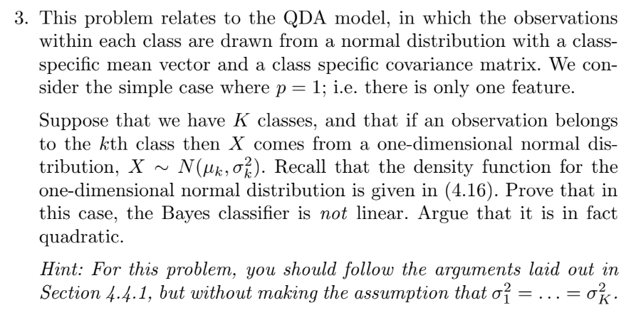

##### *3. Rezolvare:*

Înlăturând ipoteza termenilor de varianță partajați în toate clasele K, termenii din (4.12) care nu variază cu $k$:

$$C' =
\frac{\frac{1}{\sqrt{2\pi}}}{\sum_l\pi_l\frac{1}{\sqrt{2\pi}\sigma_l}\exp(-1/2\sigma_l^2(x-\mu_l)^2)}$$

Inlocuim $C'$ in (4.12) si logaritmam:

$$\begin{aligned}
P_k(x) &=
C'\frac{\pi_k}{\sigma_k}\exp(-\frac{1}{2\sigma^2}(x^2-2\mu_kx +
\mu_k^2))\\
\log(P_k(x)) &= -\frac{1}{2\sigma_k^2}x^2 +
\frac{\mu_kx}{\sigma_k^2} - \frac{\mu_k^2}{2\sigma_k^2} +
\log(\frac{\pi_k}{\sigma_k}) + \log(C')
\end{aligned}$$

Dupa cum se poate vedea din prezenta lui $x^2$ in termenul final, discriminantul nu este liniar.

##### *4.a. Cerinta:*

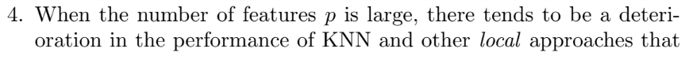

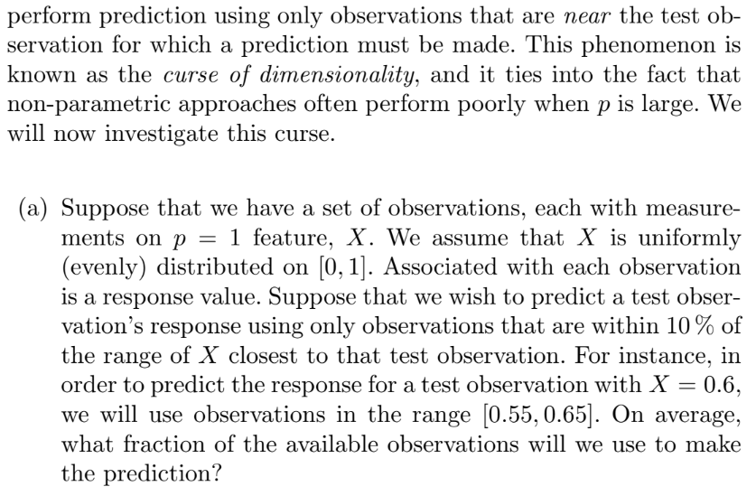

*4.a. Rezolvare:*

Într-o distribuție uniformă, toate intervalele de aceeași lungime au aceeasi probabilitate. Presupunem $x\in[0,05, 0,95]$, si intervalele: $[x-0,05, x+0,05]$, avnd $lungime=0,1$. În medie, 10% dintre observații ar fi disponibile pentru a face o predicție pentru observația de test.

##### *4.b. Cerinta:*

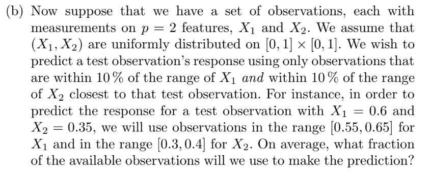

##### *4.b. Rezolvare:*

Presupunem $x\in[0.05, 0.95]$, $x1_{length} \times x2_{length} = 0.01$. Deci, 1% din observatiile disponibile ar fi folosite pentru realizarea unei predictii.

##### *4.c. Cerinta:*

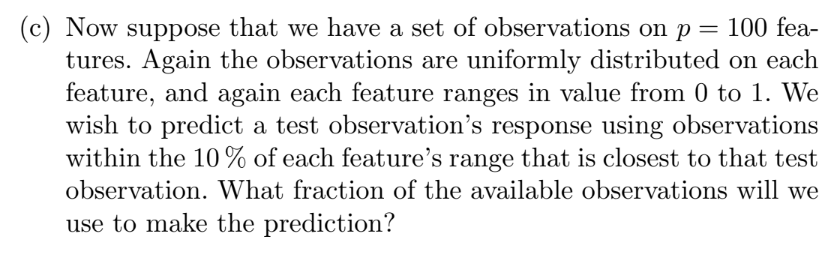

##### *4.c. Rezolvare:*

Daca p=100; $0.1^p \times 100 = 0.1^{100} \times 100$ din observatii sunt disponibile.

##### *4.d. Cerinta:*

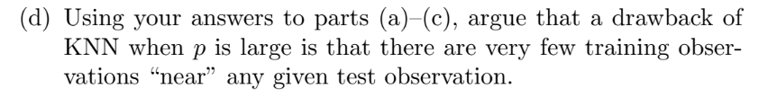

##### *4.d. Rezolvare:*

Pe măsură ce numărul de predictori crește, fracția de observații disponibile pentru a face o predicție este redusă exponențial.

##### *4.e. Cerinta:*

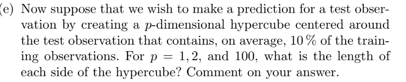

##### *4.e. Rezolvare:*

$If p=1 ; d(length) = 0.1^{1/1} = 0.1$

$If p=2 ; d(length) = 0.1^{1/2} = 0.32$

$If p=100 ; d(length) = 0.1^{1/100} = 0.977$

Pe măsură ce p crește, lungimea laturii converge la 1 și acest lucru arată că hipercubul centrat în jurul observației de test cu 10% din observația de test trebuie să aibă aproape aceeași dimensiune ca și hipercubul cu toate observațiile. De asemenea, arată că observațiile sunt „mai departe” de o observație de test pe măsură ce p crește; adică sunt concentrate lângă limita hipercubului.

##### *5. Cerinta:*

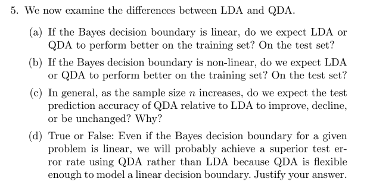

##### *5. Rezolvare:*

**(a)**

- LDA functioneaza mai bine pe date de test.
- QDA functioneaza mai bine pe date de antrenament (are mai multa flexibiliatte la potrivirea datelor), dar mai rau pe date de test din cauza cresterii variantei.

**(b)**

- QDA functioneaza mai bine pe date de antrenament si de test.

**(c)**

- În general, QDA tinde să fie mai bun decât LDA atunci când dimensiunea eșantionului este mare și unde nu există o covarianță comună între clase. Ca atare, ar fi de asteptat ca QDA să ofere o potrivire mai bună și astfel să ofere predicții mai bune.

**(d)**

- Fals: LDA va oferi probabil o potrivire mai bună pentru o limită de decizie liniară decât QDA și, prin urmare, va oferi o rată de eroare de testare mai bună. QDA ar putea oferi un model supra-adaptat (datorită flexibilității mai mari) care funcționează bine pe setul de antrenament, dar mai rău pe setul de testare (datorită variației mai mari).

##### *6. Cerinta:*

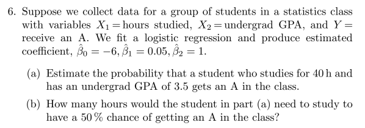

##### *6. Rezolvare:*

**(a)**

$$\begin{aligned}
P(X) &= \frac{\exp(\hat\beta_0 + \hat\beta_1X_1 + \hat\beta_2X_2)}{1
+ \exp(\hat\beta_0 + \hat\beta_1X_1 + \hat\beta_2X_2)}\\
P(X) &= \frac{\exp(-0.5)}{1+\exp(-0.5)} = 0.38
\end{aligned}$$

**(b)**

$$\begin{aligned}
\log(\frac{P(X)}{1 - P(X)}) &= \hat\beta_0 + \hat\beta_1X_1 +
\hat\beta_2X_2\\
\log(\frac{0.5}{1 - 0.5}) &= -6 + 0.05X1 + 3.5\\
X_1 &= 50 hours.
\end{aligned}$$

##### *7. Cerinta:*

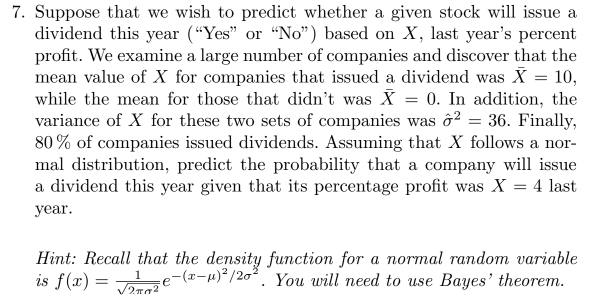

##### *7. Rezolvare:*

$$\begin{aligned}
P(Y=yes|X=4) &= \frac{\pi_{yes}f_{yes}(x)}{\sum_{l=1}^K \pi_lf_l(x)}
=
\frac{\pi_{yes}\exp(-1/2\sigma^2(x-\mu_{yes})^2)}{\sum_{l=1}^K\pi_l\exp(-1/2\sigma^2(x-\mu_l)^2)}\\
P(Y=yes|X=4) &= \frac{0.8\times\exp(-0.5)}{0.8\times\exp(-0.5) +
0.2\times\exp(-16/72)}\\
P(Y=yes|X=4) &= 0.75
\end{aligned}$$

##### *8. Cerinta:*

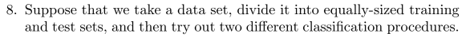

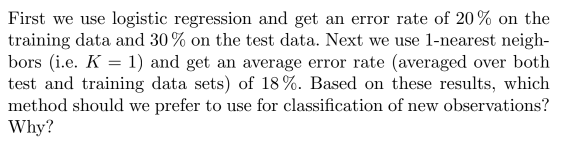

##### *8. Rezolvare:*

Modelul KNN cu K=1 s-ar potrivi exact setului de antrenament și astfel eroarea de antrenament ar fi zero. Aceasta înseamnă că eroarea de testare trebuie să fie de 36% pentru ca media erorilor să fie de 18%. Deoarece selecția modelului se bazează pe performanța setului de testare, vom alege regresia logistică pentru a clasifica noile observații.

##### *9. Cerinta:*

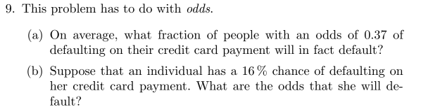

##### *9. Rezolvare:*

**(a)**

$$\begin{aligned}
Odds &= \frac{P(X)}{1-P(X)}\\
P(X) &= \frac{0.37}{1.37} = 0.27
\end{aligned}$$

- 27% of people with odds of 0.37 will default.

**(b)**

$$Odds =
\frac{0.16}{1-0.16}=0.19$$

##### *10. Cerinta:*

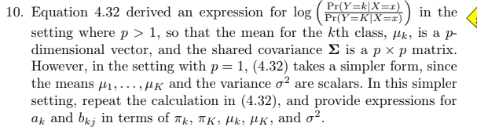

##### *10. Rezolvare:*

Daca reducem dimensionaliatatea lui p la p=1, se reduce si inversul matricei de covarianta Σ−1(X) la un scalar al inversului varianței 1σ2(x) și matricele cu x se reduc la vectori ai matricei diagonale a valorilor σ2(x), unde x este diferența dintre media ponderii clasei μk și media tuturor claselor, μK.